# Risk Factor Analysis

## Outcome Variable

**Outcome Variable:** stunted

## Predictor Variables

**Intervention Variable:** mwtkg

**Adjustment Set:**

- arm
- W_mage
- meducyrs
- feducyrs
- single
- brthmon
- W_parity
- delta_W_mage
- delta_meducyrs
- delta_feducyrs
- delta_single
- delta_brthmon
- delta_W_parity

## Stratifying Variables

The analysis was stratified on these variable(s):

- agecat
- studyid
- country

## Data Summary

| agecat | studyid | country | mwtkg | stunted | n_cell | n |
| --- | --- | --- | --- | --- | --- | --- |
| Birth | ki0047075b-MAL-ED | BANGLADESH | >=58 kg | 0 | 31 | 222 |
| Birth | ki0047075b-MAL-ED | BANGLADESH | >=58 kg | 1 | 7 | 222 |
| Birth | ki0047075b-MAL-ED | BANGLADESH | <52 kg | 0 | 114 | 222 |
| Birth | ki0047075b-MAL-ED | BANGLADESH | <52 kg | 1 | 29 | 222 |
| Birth | ki0047075b-MAL-ED | BANGLADESH | [52-58) kg | 0 | 37 | 222 |
| Birth | ki0047075b-MAL-ED | BANGLADESH | [52-58) kg | 1 | 4 | 222 |
| Birth | ki0047075b-MAL-ED | BRAZIL | >=58 kg | 0 | 31 | 64 |
| Birth | ki0047075b-MAL-ED | BRAZIL | >=58 kg | 1 | 3 | 64 |
| Birth | ki0047075b-MAL-ED | BRAZIL | <52 kg | 0 | 11 | 64 |
| Birth | ki0047075b-MAL-ED | BRAZIL | <52 kg | 1 | 4 | 64 |
| Birth | ki0047075b-MAL-ED | BRAZIL | [52-58) kg | 0 | 13 | 64 |
| Birth | ki0047075b-MAL-ED | BRAZIL | [52-58) kg | 1 | 2 | 64 |
| Birth | ki0047075b-MAL-ED | INDIA | >=58 kg | 0 | 5 | 43 |
| Birth | ki0047075b-MAL-ED | INDIA | >=58 kg | 1 | 1 | 43 |
| Birth | ki0047075b-MAL-ED | INDIA | <52 kg | 0 | 24 | 43 |
| Birth | ki0047075b-MAL-ED | INDIA | <52 kg | 1 | 5 | 43 |
| Birth | ki0047075b-MAL-ED | INDIA | [52-58) kg | 0 | 5 | 43 |
| Birth | ki0047075b-MAL-ED | INDIA | [52-58) kg | 1 | 3 | 43 |
| Birth | ki0047075b-MAL-ED | NEPAL | >=58 kg | 0 | 9 | 27 |
| Birth | ki0047075b-MAL-ED | NEPAL | >=58 kg | 1 | 0 | 27 |
| Birth | ki0047075b-MAL-ED | NEPAL | <52 kg | 0 | 6 | 27 |
| Birth | ki0047075b-MAL-ED | NEPAL | <52 kg | 1 | 2 | 27 |
| Birth | ki0047075b-MAL-ED | NEPAL | [52-58) kg | 0 | 10 | 27 |
| Birth | ki0047075b-MAL-ED | NEPAL | [52-58) kg | 1 | 0 | 27 |
| Birth | ki0047075b-MAL-ED | PERU | >=58 kg | 0 | 78 | 226 |
| Birth | ki0047075b-MAL-ED | PERU | >=58 kg | 1 | 5 | 226 |
| Birth | ki0047075b-MAL-ED | PERU | <52 kg | 0 | 68 | 226 |
| Birth | ki0047075b-MAL-ED | PERU | <52 kg | 1 | 16 | 226 |
| Birth | ki0047075b-MAL-ED | PERU | [52-58) kg | 0 | 54 | 226 |
| Birth | ki0047075b-MAL-ED | PERU | [52-58) kg | 1 | 5 | 226 |

[output cut: 240 more lines]

The following strata were considered:

- agecat: 24 months, studyid: ki0047075b-MAL-ED, country: BANGLADESH
- agecat: 24 months, studyid: ki0047075b-MAL-ED, country: BRAZIL
- agecat: 24 months, studyid: ki0047075b-MAL-ED, country: INDIA
- agecat: 24 months, studyid: ki0047075b-MAL-ED, country: NEPAL
- agecat: 24 months, studyid: ki0047075b-MAL-ED, country: PERU
- agecat: 24 months, studyid: ki0047075b-MAL-ED, country: SOUTH AFRICA
- agecat: 24 months, studyid: ki0047075b-MAL-ED, country: TANZANIA, UNITED REPUBLIC OF
- agecat: 24 months, studyid: ki1017093-NIH-Birth, country: BANGLADESH
- agecat: 24 months, studyid: ki1017093b-PROVIDE, country: BANGLADESH
- agecat: 24 months, studyid: ki1017093c-NIH-Crypto, country: BANGLADESH
- agecat: 24 months, studyid: ki1066203-TanzaniaChild2, country: TANZANIA, UNITED REPUBLIC OF
- agecat: 24 months, studyid: ki1119695-PROBIT, country: BELARUS
- agecat: 24 months, studyid: ki1126311-ZVITAMBO, country: ZIMBABWE
- agecat: 24 months, studyid: ki1148112-LCNI-5, country: MALAWI
- agecat: 24 months, studyid: kiGH5241-JiVitA-3, country: BANGLADESH
- agecat: 6 months, studyid: ki0047075b-MAL-ED, country: BANGLADESH
- agecat: 6 months, studyid: ki0047075b-MAL-ED, country: BRAZIL
- agecat: 6 months, studyid: ki0047075b-MAL-ED, country: INDIA
- agecat: 6 months, studyid: ki0047075b-MAL-ED, country: NEPAL
- agecat: 6 months, studyid: ki0047075b-MAL-ED, country: PERU
- agecat: 6 months, studyid: ki0047075b-MAL-ED, country: SOUTH AFRICA
- agecat: 6 months, studyid: ki0047075b-MAL-ED, country: TANZANIA, UNITED REPUBLIC OF
- agecat: 6 months, studyid: ki1000304b-SAS-CompFeed, country: INDIA
- agecat: 6 months, studyid: ki1017093-NIH-Birth, country: BANGLADESH
- agecat: 6 months, studyid: ki1017093b-PROVIDE, country: BANGLADESH
- agecat: 6 months, studyid: ki1017093c-NIH-Crypto, country: BANGLADESH
- agecat: 6 months, studyid: ki1066203-TanzaniaChild2, country: TANZANIA, UNITED REPUBLIC OF
- agecat: 6 months, studyid: ki1119695-PROBIT, country: BELARUS
- agecat: 6 months, studyid: ki1126311-ZVITAMBO, country: ZIMBABWE
- agecat: 6 months, studyid: ki1148112-LCNI-5, country: MALAWI
- agecat: 6 months, studyid: kiGH5241-JiVitA-3, country: BANGLADESH
- agecat: Birth, studyid: ki0047075b-MAL-ED, country: BANGLADESH
- agecat: Birth, studyid: ki0047075b-MAL-ED, country: BRAZIL
- agecat: Birth, studyid: ki0047075b-MAL-ED, country: INDIA
- agecat: Birth, studyid: ki0047075b-MAL-ED, country: NEPAL
- agecat: Birth, studyid: ki0047075b-MAL-ED, country: PERU
- agecat: Birth, studyid: ki0047075b-MAL-ED, country: SOUTH AFRICA
- agecat: Birth, studyid: ki0047075b-MAL-ED, country: TANZANIA, UNITED REPUBLIC OF
- agecat: Birth, studyid: ki1000304b-SAS-CompFeed, country: INDIA
- agecat: Birth, studyid: ki1017093-NIH-Birth, country: BANGLADESH
- agecat: Birth, studyid: ki1017093b-PROVIDE, country: BANGLADESH
- agecat: Birth, studyid: ki1017093c-NIH-Crypto, country: BANGLADESH
- agecat: Birth, studyid: ki1119695-PROBIT, country: BELARUS
- agecat: Birth, studyid: ki1126311-ZVITAMBO, country: ZIMBABWE
- agecat: Birth, studyid: kiGH5241-JiVitA-3, country: BANGLADESH

### Dropped Strata

Some strata were dropped due to rare outcomes:

- agecat: Birth, studyid: ki0047075b-MAL-ED, country: BANGLADESH
- agecat: Birth, studyid: ki0047075b-MAL-ED, country: BRAZIL
- agecat: Birth, studyid: ki0047075b-MAL-ED, country: INDIA
- agecat: Birth, studyid: ki0047075b-MAL-ED, country: NEPAL
- agecat: Birth, studyid: ki0047075b-MAL-ED, country: SOUTH AFRICA
- agecat: Birth, studyid: ki0047075b-MAL-ED, country: TANZANIA, UNITED REPUBLIC OF
- agecat: Birth, studyid: ki1017093b-PROVIDE, country: BANGLADESH
- agecat: 6 months, studyid: ki0047075b-MAL-ED, country: BANGLADESH
- agecat: 6 months, studyid: ki0047075b-MAL-ED, country: BRAZIL
- agecat: 6 months, studyid: ki0047075b-MAL-ED, country: INDIA
- agecat: 6 months, studyid: ki0047075b-MAL-ED, country: NEPAL
- agecat: 24 months, studyid: ki0047075b-MAL-ED, country: BRAZIL
- agecat: 24 months, studyid: ki1066203-TanzaniaChild2, country: TANZANIA, UNITED REPUBLIC OF

## Methods Detail

We’re interested in the causal parameters $E[Y_a]$ for all values of $a \in \mathcal{A}$. These parameters represent the mean outcome if, possibly contrary to fact, we intervened to set all units to have $A=a$. Under the randomization and positivity assumptions, these are identified by the statistical parameters $\psi_a=E_W[E_{Y|A,W}(Y|A=a,W)]$. In addition, we’re interested in the mean of $Y$, $E[Y]$ under no intervention (the observed mean). We will estimate these parameters by using SuperLearner to fit the relevant likelihood factors – $E_{Y|A,W}(Y|A=a,W)$ and $p(A=a|W)$, and then updating our likelihood fit using a joint TMLE.

For unadjusted analyses ($W=\{\}$), initial likelihoods were estimated using Lrnr_glm to estimate the simple $E(Y|A)$ and Lrnr_mean to estimate $p(A)$. For adjusted analyses, a small library containing Lrnr_glmnet, Lrnr_xgboost, and Lrnr_mean was used.

Having estimated these parameters, we will then use the delta method to estimate relative risks and attributable risks relative to a prespecified baseline level of $A$.

# Results Detail

## Results Plots

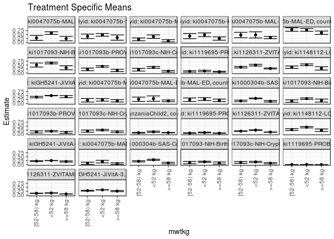

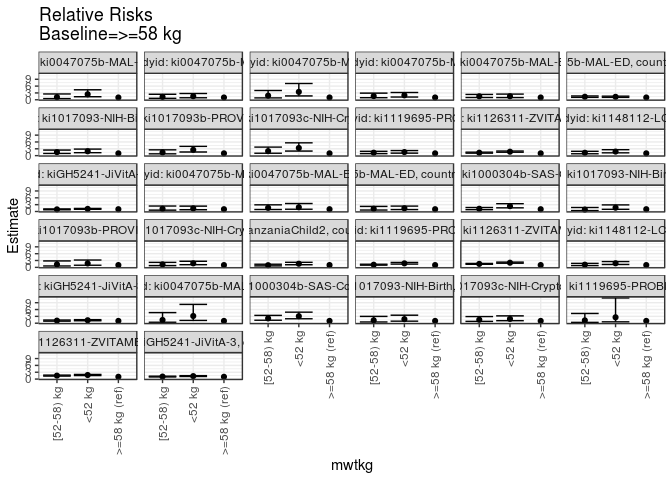

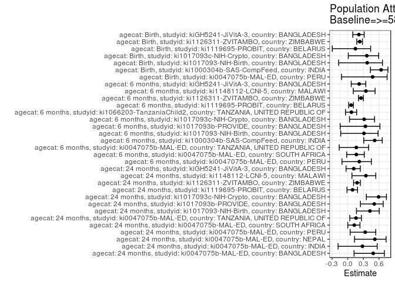

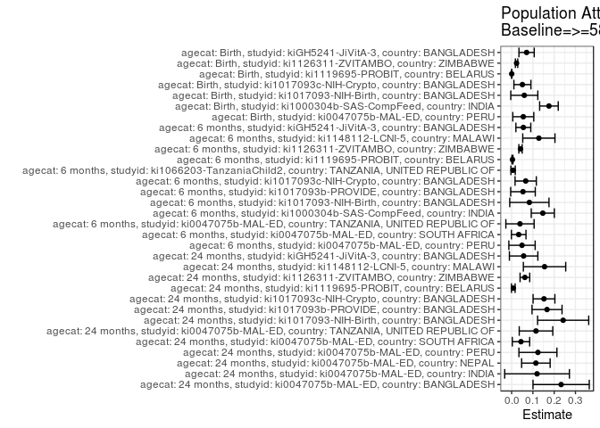

## Results Table

### Parameter: TSM

| agecat | studyid | country | intervention_level | baseline_level | estimate | ci_lower | ci_upper |
| --- | --- | --- | --- | --- | --- | --- | --- |
| Birth | ki0047075b-MAL-ED | PERU | >=58 kg | NA | 0.0602410 | 0.0089399 | 0.1115420 |
| Birth | ki0047075b-MAL-ED | PERU | <52 kg | NA | 0.1904762 | 0.1063160 | 0.2746364 |
| Birth | ki0047075b-MAL-ED | PERU | [52-58) kg | NA | 0.0847458 | 0.0135236 | 0.1559679 |
| Birth | ki1000304b-SAS-CompFeed | INDIA | >=58 kg | NA | 0.0989011 | 0.0494314 | 0.1483708 |
| Birth | ki1000304b-SAS-CompFeed | INDIA | <52 kg | NA | 0.3045311 | 0.2684154 | 0.3406468 |
| Birth | ki1000304b-SAS-CompFeed | INDIA | [52-58) kg | NA | 0.2091837 | 0.1698398 | 0.2485275 |
| Birth | ki1017093-NIH-Birth | BANGLADESH | >=58 kg | NA | 0.1000000 | 0.0342067 | 0.1657933 |
| Birth | ki1017093-NIH-Birth | BANGLADESH | <52 kg | NA | 0.1768707 | 0.1412299 | 0.2125116 |
| Birth | ki1017093-NIH-Birth | BANGLADESH | [52-58) kg | NA | 0.1264368 | 0.0565444 | 0.1963292 |
| Birth | ki1017093c-NIH-Crypto | BANGLADESH | >=58 kg | NA | 0.0878655 | 0.0454770 | 0.1302540 |
| Birth | ki1017093c-NIH-Crypto | BANGLADESH | <52 kg | NA | 0.1664151 | 0.1296602 | 0.2031700 |
| Birth | ki1017093c-NIH-Crypto | BANGLADESH | [52-58) kg | NA | 0.1336047 | 0.0755819 | 0.1916275 |
| Birth | ki1119695-PROBIT | BELARUS | >=58 kg | NA | 0.0020440 | 0.0003496 | 0.0037384 |
| Birth | ki1119695-PROBIT | BELARUS | <52 kg | NA | 0.0053050 | -0.0001768 | 0.0107869 |
| Birth | ki1119695-PROBIT | BELARUS | [52-58) kg | NA | 0.0025402 | 0.0003101 | 0.0047704 |
| Birth | ki1126311-ZVITAMBO | ZIMBABWE | >=58 kg | NA | 0.0778945 | 0.0709182 | 0.0848708 |
| Birth | ki1126311-ZVITAMBO | ZIMBABWE | <52 kg | NA | 0.1383752 | 0.1240348 | 0.1527156 |
| Birth | ki1126311-ZVITAMBO | ZIMBABWE | [52-58) kg | NA | 0.1174520 | 0.1054159 | 0.1294881 |
| Birth | kiGH5241-JiVitA-3 | BANGLADESH | >=58 kg | NA | 0.2585918 | 0.2224540 | 0.2947297 |
| Birth | kiGH5241-JiVitA-3 | BANGLADESH | <52 kg | NA | 0.3340489 | 0.3264625 | 0.3416352 |
| Birth | kiGH5241-JiVitA-3 | BANGLADESH | [52-58) kg | NA | 0.2814614 | 0.2554276 | 0.3074952 |
| 6 months | ki0047075b-MAL-ED | PERU | >=58 kg | NA | 0.1718006 | 0.0996568 | 0.2439443 |
| 6 months | ki0047075b-MAL-ED | PERU | <52 kg | NA | 0.2322017 | 0.1505262 | 0.3138772 |
| 6 months | ki0047075b-MAL-ED | PERU | [52-58) kg | NA | 0.2063077 | 0.0920246 | 0.3205908 |
| 6 months | ki0047075b-MAL-ED | SOUTH AFRICA | >=58 kg | NA | 0.1675978 | 0.1127706 | 0.2224250 |
| 6 months | ki0047075b-MAL-ED | SOUTH AFRICA | <52 kg | NA | 0.3103448 | 0.1416269 | 0.4790627 |
| 6 months | ki0047075b-MAL-ED | SOUTH AFRICA | [52-58) kg | NA | 0.2682927 | 0.1323978 | 0.4041876 |
| 6 months | ki0047075b-MAL-ED | TANZANIA, UNITED REPUBLIC OF | >=58 kg | NA | 0.1995639 | 0.1188146 | 0.2803133 |
| 6 months | ki0047075b-MAL-ED | TANZANIA, UNITED REPUBLIC OF | <52 kg | NA | 0.2811878 | 0.1895140 | 0.3728616 |
| 6 months | ki0047075b-MAL-ED | TANZANIA, UNITED REPUBLIC OF | [52-58) kg | NA | 0.2400181 | 0.1270775 | 0.3529586 |

[output cut: 66 more lines]

### Parameter: E(Y)

| agecat | studyid | country | intervention_level | baseline_level | estimate | ci_lower | ci_upper |
| --- | --- | --- | --- | --- | --- | --- | --- |
| Birth | ki0047075b-MAL-ED | PERU | NA | NA | 0.1150442 | 0.0733525 | 0.1567360 |
| Birth | ki1000304b-SAS-CompFeed | INDIA | NA | NA | 0.2742718 | 0.2403806 | 0.3081631 |
| Birth | ki1017093-NIH-Birth | BANGLADESH | NA | NA | 0.1595395 | 0.1304091 | 0.1886699 |
| Birth | ki1017093c-NIH-Crypto | BANGLADESH | NA | NA | 0.1385460 | 0.1134505 | 0.1636414 |
| Birth | ki1119695-PROBIT | BELARUS | NA | NA | 0.0023970 | 0.0011029 | 0.0036912 |
| Birth | ki1126311-ZVITAMBO | ZIMBABWE | NA | NA | 0.1010788 | 0.0954534 | 0.1067041 |
| Birth | kiGH5241-JiVitA-3 | BANGLADESH | NA | NA | 0.3289051 | 0.3215448 | 0.3362655 |
| 6 months | ki0047075b-MAL-ED | PERU | NA | NA | 0.2205882 | 0.1712211 | 0.2699554 |
| 6 months | ki0047075b-MAL-ED | SOUTH AFRICA | NA | NA | 0.2008032 | 0.1509453 | 0.2506612 |
| 6 months | ki0047075b-MAL-ED | TANZANIA, UNITED REPUBLIC OF | NA | NA | 0.2388664 | 0.1855834 | 0.2921494 |
| 6 months | ki1000304b-SAS-CompFeed | INDIA | NA | NA | 0.2839970 | 0.2655949 | 0.3023990 |
| 6 months | ki1017093-NIH-Birth | BANGLADESH | NA | NA | 0.2681564 | 0.2306532 | 0.3056597 |
| 6 months | ki1017093b-PROVIDE | BANGLADESH | NA | NA | 0.1575456 | 0.1284434 | 0.1866478 |
| 6 months | ki1017093c-NIH-Crypto | BANGLADESH | NA | NA | 0.2097902 | 0.1799252 | 0.2396552 |
| 6 months | ki1066203-TanzaniaChild2 | TANZANIA, UNITED REPUBLIC OF | NA | NA | 0.0965309 | 0.0835493 | 0.1095126 |
| 6 months | ki1119695-PROBIT | BELARUS | NA | NA | 0.0598408 | 0.0469716 | 0.0727101 |
| 6 months | ki1126311-ZVITAMBO | ZIMBABWE | NA | NA | 0.1640417 | 0.1560523 | 0.1720310 |
| 6 months | ki1148112-LCNI-5 | MALAWI | NA | NA | 0.3679809 | 0.3352903 | 0.4006715 |
| 6 months | kiGH5241-JiVitA-3 | BANGLADESH | NA | NA | 0.2514582 | 0.2433372 | 0.2595791 |
| 24 months | ki0047075b-MAL-ED | BANGLADESH | NA | NA | 0.4764151 | 0.4090254 | 0.5438047 |
| 24 months | ki0047075b-MAL-ED | INDIA | NA | NA | 0.4247788 | 0.3601902 | 0.4893673 |
| 24 months | ki0047075b-MAL-ED | NEPAL | NA | NA | 0.2192982 | 0.1654718 | 0.2731246 |
| 24 months | ki0047075b-MAL-ED | PERU | NA | NA | 0.3681592 | 0.3013164 | 0.4350020 |
| 24 months | ki0047075b-MAL-ED | SOUTH AFRICA | NA | NA | 0.3504274 | 0.2891665 | 0.4116882 |
| 24 months | ki0047075b-MAL-ED | TANZANIA, UNITED REPUBLIC OF | NA | NA | 0.7242991 | 0.6642873 | 0.7843108 |
| 24 months | ki1017093-NIH-Birth | BANGLADESH | NA | NA | 0.5687646 | 0.5218455 | 0.6156837 |
| 24 months | ki1017093b-PROVIDE | BANGLADESH | NA | NA | 0.3275563 | 0.2892291 | 0.3658836 |
| 24 months | ki1017093c-NIH-Crypto | BANGLADESH | NA | NA | 0.2568093 | 0.2190047 | 0.2946140 |
| 24 months | ki1119695-PROBIT | BELARUS | NA | NA | 0.0852230 | 0.0552609 | 0.1151851 |
| 24 months | ki1126311-ZVITAMBO | ZIMBABWE | NA | NA | 0.3469773 | 0.3235580 | 0.3703967 |
| 24 months | ki1148112-LCNI-5 | MALAWI | NA | NA | 0.4446367 | 0.4040904 | 0.4851830 |
| 24 months | kiGH5241-JiVitA-3 | BANGLADESH | NA | NA | 0.4910166 | 0.4779105 | 0.5041227 |

### Parameter: RR

| agecat | studyid | country | intervention_level | baseline_level | estimate | ci_lower | ci_upper |
| --- | --- | --- | --- | --- | --- | --- | --- |
| Birth | ki0047075b-MAL-ED | PERU | >=58 kg | >=58 kg | 1.0000000 | 1.0000000 | 1.000000 |
| Birth | ki0047075b-MAL-ED | PERU | <52 kg | >=58 kg | 3.1619048 | 1.2114019 | 8.252952 |
| Birth | ki0047075b-MAL-ED | PERU | [52-58) kg | >=58 kg | 1.4067797 | 0.4252149 | 4.654186 |
| Birth | ki1000304b-SAS-CompFeed | INDIA | >=58 kg | >=58 kg | 1.0000000 | 1.0000000 | 1.000000 |
| Birth | ki1000304b-SAS-CompFeed | INDIA | <52 kg | >=58 kg | 3.0791476 | 1.9560693 | 4.847042 |
| Birth | ki1000304b-SAS-CompFeed | INDIA | [52-58) kg | >=58 kg | 2.1150793 | 1.3057415 | 3.426069 |
| Birth | ki1017093-NIH-Birth | BANGLADESH | >=58 kg | >=58 kg | 1.0000000 | 1.0000000 | 1.000000 |
| Birth | ki1017093-NIH-Birth | BANGLADESH | <52 kg | >=58 kg | 1.7687075 | 0.8888286 | 3.519606 |
| Birth | ki1017093-NIH-Birth | BANGLADESH | [52-58) kg | >=58 kg | 1.2643678 | 0.5353913 | 2.985902 |
| Birth | ki1017093c-NIH-Crypto | BANGLADESH | >=58 kg | >=58 kg | 1.0000000 | 1.0000000 | 1.000000 |
| Birth | ki1017093c-NIH-Crypto | BANGLADESH | <52 kg | >=58 kg | 1.8939761 | 1.1139047 | 3.220334 |
| Birth | ki1017093c-NIH-Crypto | BANGLADESH | [52-58) kg | >=58 kg | 1.5205601 | 0.7951563 | 2.907734 |
| Birth | ki1119695-PROBIT | BELARUS | >=58 kg | >=58 kg | 1.0000000 | 1.0000000 | 1.000000 |
| Birth | ki1119695-PROBIT | BELARUS | <52 kg | >=58 kg | 2.5954276 | 0.6078635 | 11.081836 |
| Birth | ki1119695-PROBIT | BELARUS | [52-58) kg | >=58 kg | 1.2427725 | 0.3611349 | 4.276749 |
| Birth | ki1126311-ZVITAMBO | ZIMBABWE | >=58 kg | >=58 kg | 1.0000000 | 1.0000000 | 1.000000 |
| Birth | ki1126311-ZVITAMBO | ZIMBABWE | <52 kg | >=58 kg | 1.7764431 | 1.5490011 | 2.037281 |
| Birth | ki1126311-ZVITAMBO | ZIMBABWE | [52-58) kg | >=58 kg | 1.5078337 | 1.3159514 | 1.727695 |
| Birth | kiGH5241-JiVitA-3 | BANGLADESH | >=58 kg | >=58 kg | 1.0000000 | 1.0000000 | 1.000000 |
| Birth | kiGH5241-JiVitA-3 | BANGLADESH | <52 kg | >=58 kg | 1.2917998 | 1.1209915 | 1.488635 |
| Birth | kiGH5241-JiVitA-3 | BANGLADESH | [52-58) kg | >=58 kg | 1.0884388 | 0.9259272 | 1.279473 |
| 6 months | ki0047075b-MAL-ED | PERU | >=58 kg | >=58 kg | 1.0000000 | 1.0000000 | 1.000000 |
| 6 months | ki0047075b-MAL-ED | PERU | <52 kg | >=58 kg | 1.3515772 | 0.7762267 | 2.353386 |
| 6 months | ki0047075b-MAL-ED | PERU | [52-58) kg | >=58 kg | 1.2008557 | 0.5993137 | 2.406176 |
| 6 months | ki0047075b-MAL-ED | SOUTH AFRICA | >=58 kg | >=58 kg | 1.0000000 | 1.0000000 | 1.000000 |
| 6 months | ki0047075b-MAL-ED | SOUTH AFRICA | <52 kg | >=58 kg | 1.8517241 | 0.9818013 | 3.492440 |
| 6 months | ki0047075b-MAL-ED | SOUTH AFRICA | [52-58) kg | >=58 kg | 1.6008130 | 0.8759360 | 2.925559 |
| 6 months | ki0047075b-MAL-ED | TANZANIA, UNITED REPUBLIC OF | >=58 kg | >=58 kg | 1.0000000 | 1.0000000 | 1.000000 |
| 6 months | ki0047075b-MAL-ED | TANZANIA, UNITED REPUBLIC OF | <52 kg | >=58 kg | 1.4090109 | 0.8360548 | 2.374619 |
| 6 months | ki0047075b-MAL-ED | TANZANIA, UNITED REPUBLIC OF | [52-58) kg | >=58 kg | 1.2027127 | 0.6467192 | 2.236701 |

[output cut: 66 more lines]

### Parameter: PAR

| agecat | studyid | country | intervention_level | baseline_level | estimate | ci_lower | ci_upper |
| --- | --- | --- | --- | --- | --- | --- | --- |
| Birth | ki0047075b-MAL-ED | PERU | >=58 kg | NA | 0.0548033 | 0.0054382 | 0.1041683 |
| Birth | ki1000304b-SAS-CompFeed | INDIA | >=58 kg | NA | 0.1753707 | 0.1316984 | 0.2190431 |
| Birth | ki1017093-NIH-Birth | BANGLADESH | >=58 kg | NA | 0.0595395 | -0.0040073 | 0.1230863 |
| Birth | ki1017093c-NIH-Crypto | BANGLADESH | >=58 kg | NA | 0.0506805 | 0.0106767 | 0.0906842 |
| Birth | ki1119695-PROBIT | BELARUS | >=58 kg | NA | 0.0003530 | -0.0004288 | 0.0011348 |
| Birth | ki1126311-ZVITAMBO | ZIMBABWE | >=58 kg | NA | 0.0231842 | 0.0176739 | 0.0286946 |
| Birth | kiGH5241-JiVitA-3 | BANGLADESH | >=58 kg | NA | 0.0703133 | 0.0344225 | 0.1062041 |
| 6 months | ki0047075b-MAL-ED | PERU | >=58 kg | NA | 0.0487877 | -0.0130755 | 0.1106508 |
| 6 months | ki0047075b-MAL-ED | SOUTH AFRICA | >=58 kg | NA | 0.0332054 | -0.0009987 | 0.0674096 |
| 6 months | ki0047075b-MAL-ED | TANZANIA, UNITED REPUBLIC OF | >=58 kg | NA | 0.0393025 | -0.0271784 | 0.1057833 |
| 6 months | ki1000304b-SAS-CompFeed | INDIA | >=58 kg | NA | 0.1464920 | 0.0921991 | 0.2007849 |
| 6 months | ki1017093-NIH-Birth | BANGLADESH | >=58 kg | NA | 0.0833945 | -0.0088514 | 0.1756404 |
| 6 months | ki1017093b-PROVIDE | BANGLADESH | >=58 kg | NA | 0.0533333 | -0.0044787 | 0.1111452 |
| 6 months | ki1017093c-NIH-Crypto | BANGLADESH | >=58 kg | NA | 0.0661007 | 0.0161723 | 0.1160291 |
| 6 months | ki1066203-TanzaniaChild2 | TANZANIA, UNITED REPUBLIC OF | >=58 kg | NA | 0.0067777 | -0.0035138 | 0.0170691 |
| 6 months | ki1119695-PROBIT | BELARUS | >=58 kg | NA | 0.0038652 | 0.0014093 | 0.0063212 |
| 6 months | ki1126311-ZVITAMBO | ZIMBABWE | >=58 kg | NA | 0.0416957 | 0.0339131 | 0.0494783 |
| 6 months | ki1148112-LCNI-5 | MALAWI | >=58 kg | NA | 0.1280143 | 0.0522698 | 0.2037589 |
| 6 months | kiGH5241-JiVitA-3 | BANGLADESH | >=58 kg | NA | 0.0550041 | 0.0200083 | 0.0900000 |
| 24 months | ki0047075b-MAL-ED | BANGLADESH | >=58 kg | NA | 0.2326733 | 0.1004652 | 0.3648814 |
| 24 months | ki0047075b-MAL-ED | INDIA | >=58 kg | NA | 0.1195354 | -0.0325786 | 0.2716494 |
| 24 months | ki0047075b-MAL-ED | NEPAL | >=58 kg | NA | 0.1140351 | 0.0470193 | 0.1810508 |
| 24 months | ki0047075b-MAL-ED | PERU | >=58 kg | NA | 0.1235894 | 0.0342260 | 0.2129529 |
| 24 months | ki0047075b-MAL-ED | SOUTH AFRICA | >=58 kg | NA | 0.0439299 | 0.0030971 | 0.0847626 |
| 24 months | ki0047075b-MAL-ED | TANZANIA, UNITED REPUBLIC OF | >=58 kg | NA | 0.1145430 | 0.0356875 | 0.1933984 |
| 24 months | ki1017093-NIH-Birth | BANGLADESH | >=58 kg | NA | 0.2422173 | 0.1220499 | 0.3623847 |
| 24 months | ki1017093b-PROVIDE | BANGLADESH | >=58 kg | NA | 0.1663471 | 0.0957654 | 0.2369288 |
| 24 months | ki1017093c-NIH-Crypto | BANGLADESH | >=58 kg | NA | 0.1520773 | 0.1008063 | 0.2033483 |
| 24 months | ki1119695-PROBIT | BELARUS | >=58 kg | NA | 0.0078965 | -0.0006792 | 0.0164721 |
| 24 months | ki1126311-ZVITAMBO | ZIMBABWE | >=58 kg | NA | 0.0622659 | 0.0396441 | 0.0848878 |
| 24 months | ki1148112-LCNI-5 | MALAWI | >=58 kg | NA | 0.1547595 | 0.0551960 | 0.2543230 |
| 24 months | kiGH5241-JiVitA-3 | BANGLADESH | >=58 kg | NA | 0.0563393 | -0.0105119 | 0.1231906 |

### Parameter: PAF

| agecat | studyid | country | intervention_level | baseline_level | estimate | ci_lower | ci_upper |
| --- | --- | --- | --- | --- | --- | --- | --- |
| Birth | ki0047075b-MAL-ED | PERU | >=58 kg | NA | 0.4763670 | -0.1196867 | 0.7551176 |
| Birth | ki1000304b-SAS-CompFeed | INDIA | >=58 kg | NA | 0.6394048 | 0.4340269 | 0.7702561 |
| Birth | ki1017093-NIH-Birth | BANGLADESH | >=58 kg | NA | 0.3731959 | -0.1749439 | 0.6656152 |
| Birth | ki1017093c-NIH-Crypto | BANGLADESH | >=58 kg | NA | 0.3658028 | 0.0107376 | 0.5934283 |
| Birth | ki1119695-PROBIT | BELARUS | >=58 kg | NA | 0.1472826 | -0.2965904 | 0.4392008 |
| Birth | ki1126311-ZVITAMBO | ZIMBABWE | >=58 kg | NA | 0.2293681 | 0.1742367 | 0.2808187 |
| Birth | kiGH5241-JiVitA-3 | BANGLADESH | >=58 kg | NA | 0.2137799 | 0.0969805 | 0.3154721 |
| 6 months | ki0047075b-MAL-ED | PERU | >=58 kg | NA | 0.2211708 | -0.1103411 | 0.4537039 |
| 6 months | ki0047075b-MAL-ED | SOUTH AFRICA | >=58 kg | NA | 0.1653631 | -0.0200531 | 0.3170760 |
| 6 months | ki0047075b-MAL-ED | TANZANIA, UNITED REPUBLIC OF | >=58 kg | NA | 0.1645374 | -0.1637818 | 0.4002331 |
| 6 months | ki1000304b-SAS-CompFeed | INDIA | >=58 kg | NA | 0.5158224 | 0.3075047 | 0.6614737 |
| 6 months | ki1017093-NIH-Birth | BANGLADESH | >=58 kg | NA | 0.3109920 | -0.1350651 | 0.5817579 |
| 6 months | ki1017093b-PROVIDE | BANGLADESH | >=58 kg | NA | 0.3385258 | -0.1447208 | 0.6177688 |
| 6 months | ki1017093c-NIH-Crypto | BANGLADESH | >=58 kg | NA | 0.3150802 | 0.0341001 | 0.5143232 |
| 6 months | ki1066203-TanzaniaChild2 | TANZANIA, UNITED REPUBLIC OF | >=58 kg | NA | 0.0702124 | -0.0423575 | 0.1706252 |
| 6 months | ki1119695-PROBIT | BELARUS | >=58 kg | NA | 0.0645916 | 0.0191367 | 0.1079401 |
| 6 months | ki1126311-ZVITAMBO | ZIMBABWE | >=58 kg | NA | 0.2541775 | 0.2064168 | 0.2990638 |
| 6 months | ki1148112-LCNI-5 | MALAWI | >=58 kg | NA | 0.3478831 | 0.1061586 | 0.5242373 |
| 6 months | kiGH5241-JiVitA-3 | BANGLADESH | >=58 kg | NA | 0.2187407 | 0.0665966 | 0.3460855 |
| 24 months | ki0047075b-MAL-ED | BANGLADESH | >=58 kg | NA | 0.4883836 | 0.1210208 | 0.7022098 |
| 24 months | ki0047075b-MAL-ED | INDIA | >=58 kg | NA | 0.2814063 | -0.1850316 | 0.5642505 |
| 24 months | ki0047075b-MAL-ED | NEPAL | >=58 kg | NA | 0.5200000 | 0.1299938 | 0.7351743 |
| 24 months | ki0047075b-MAL-ED | PERU | >=58 kg | NA | 0.3356956 | 0.0460462 | 0.5373986 |
| 24 months | ki0047075b-MAL-ED | SOUTH AFRICA | >=58 kg | NA | 0.1253608 | 0.0007181 | 0.2344566 |
| 24 months | ki0047075b-MAL-ED | TANZANIA, UNITED REPUBLIC OF | >=58 kg | NA | 0.1581432 | 0.0388790 | 0.2626081 |
| 24 months | ki1017093-NIH-Birth | BANGLADESH | >=58 kg | NA | 0.4258657 | 0.1675766 | 0.6040113 |
| 24 months | ki1017093b-PROVIDE | BANGLADESH | >=58 kg | NA | 0.5078426 | 0.2435691 | 0.6797872 |
| 24 months | ki1017093c-NIH-Crypto | BANGLADESH | >=58 kg | NA | 0.5921799 | 0.3567649 | 0.7414363 |
| 24 months | ki1119695-PROBIT | BELARUS | >=58 kg | NA | 0.0926568 | -0.0143681 | 0.1883895 |
| 24 months | ki1126311-ZVITAMBO | ZIMBABWE | >=58 kg | NA | 0.1794525 | 0.1118151 | 0.2419391 |
| 24 months | ki1148112-LCNI-5 | MALAWI | >=58 kg | NA | 0.3480582 | 0.0803350 | 0.5378447 |
| 24 months | kiGH5241-JiVitA-3 | BANGLADESH | >=58 kg | NA | 0.1147402 | -0.0324611 | 0.2409545 |